# Specifying uniform/range priors in Stan when the boundary for one parameter depends on another

This code lives [here](https://github.com/ChrisHIV/teaching).

Consider the following Stan code (stored as a string in R) which simply samples variables $x$ and $y$ from their priors

```r
model_1 <- "
parameters {
  real<lower = 0, upper = 1> x;
  real<lower = 0, upper = x> y;
}
model {}
"
```

My intention here is that $x$ should have a uniform distribution from 0 to 1, and $y$ given $x$ should have a uniform distribution from 0 to $x$. However this is not how Stan will interpret this code, as we can see by sampling from this model:

```r
library(tidyverse)
library(rstan)
options(mc.cores = parallel::detectCores()) # parallelise
rstan_options(auto_write = TRUE)            # avoid re-compiling stan code
theme_set(theme_classic())

model_compiled <- stan_model(model_code = model_1)

fit <- sampling(model_compiled,
                iter = 100000,
                chains = 1)
```

Gather all the samples from the posterior into a long dataframe and plot:

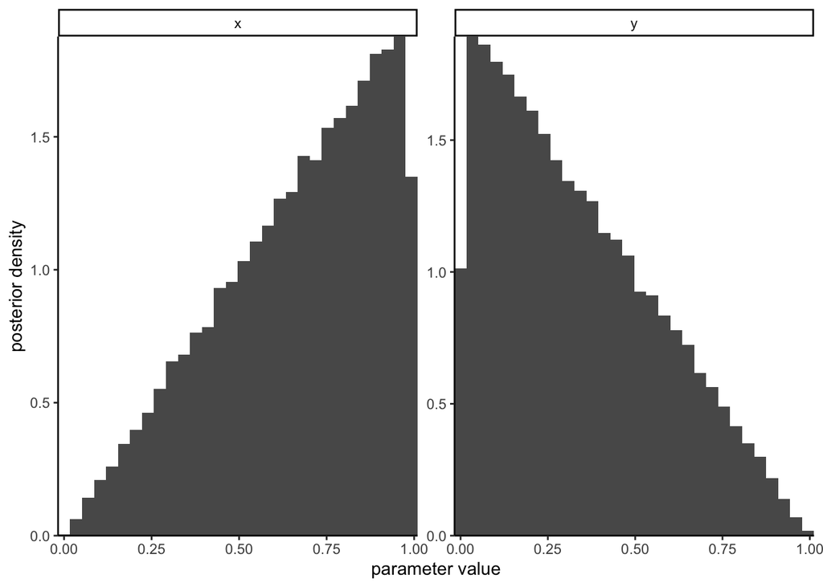

```r
df_fit <- fit %>%
  as.data.frame() %>%
  as_tibble() %>%
  mutate(sample = row_number()) %>%
  pivot_longer(-sample, names_to = "parameter")

ggplot(df_fit %>% filter(parameter != "lp__")) +
  geom_histogram(aes(value, ..density..)) +
  facet_wrap(~parameter, scales = "free", nrow = 1) +
  labs(x = "parameter value",
       y = "posterior density") +
  coord_cartesian(expand = F)
```

$x$ does not have a uniform distribution as intended. Also, the unconditional distribution $P(y)$ is not what was intended (see the note at the bottom). The easiest way to get what we intended is to explicitly specify the uniform prior desired for $y$ given $x$ in the model block, which we don’t normally need to do when the boundaries of the uniform distribution are constant, because it’s implicit.

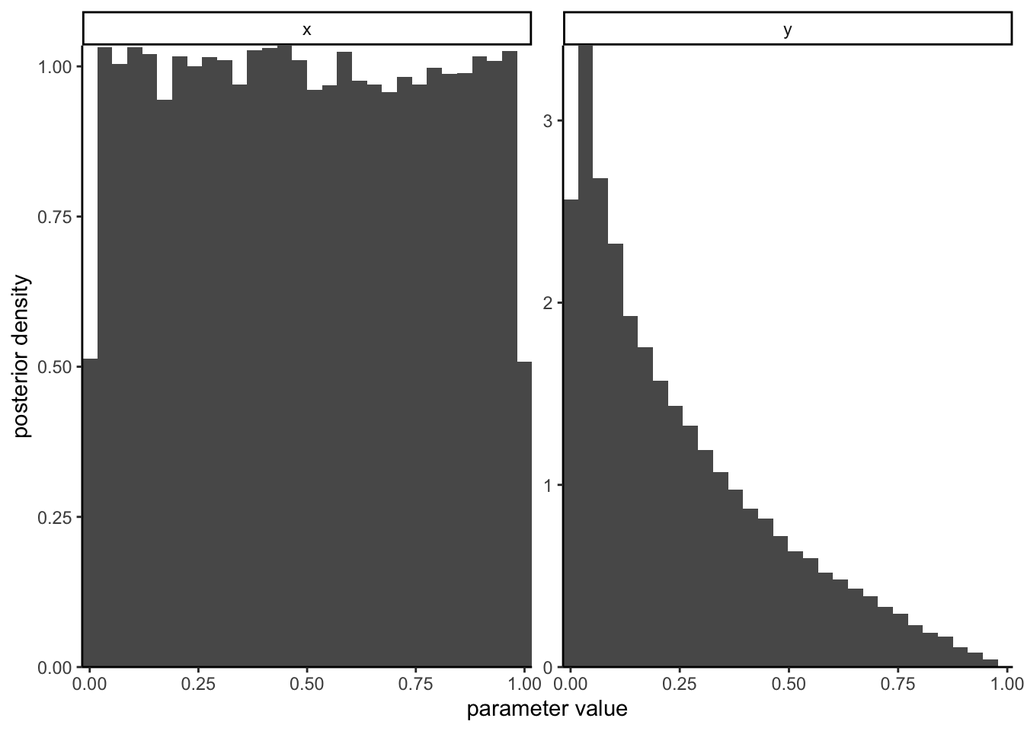

```r
model_2 <- "
parameters {
  real<lower = 0, upper = 1> x;
  real<lower = 0, upper = x> y;
}
model {
  y ~ uniform(0, x);
}
"

model_compiled <- stan_model(model_code = model_2)

fit <- sampling(model_compiled,
                iter = 100000,
                chains = 1)

df_fit <- fit %>%
  as.data.frame() %>%
  as_tibble() %>%
  mutate(sample = row_number()) %>%
  pivot_longer(-sample, names_to = "parameter")

ggplot(df_fit %>% filter(parameter != "lp__")) +
  geom_histogram(aes(value, ..density..)) +
  facet_wrap(~parameter, scales = "free", nrow = 1) +
  labs(x = "parameter value",
       y = "posterior density") +
  coord_cartesian(expand = F)
```

Now we have what was intended.  
Equivalently we could have coded that model like this:

```r
model_3 <- "
parameters {
  real<lower = 0, upper = 1> x;
  real<lower = 0, upper = 1> y_unscaled;
}
transformed parameters {
  real y = y_unscaled * x;
}
model {}
"
```

**Note on the unconditional $P(y)$ distribution**: with the model above, i.e. $x\sim \text{Uniform}(0,1)$ and $y|x\sim \text{Uniform}(0,x)$, the unconditional distribution for y is $P(y) = \int_{x=0}^1 P(y|x)P(x)dx = -\log_ey$, which diverges as $y \rightarrow 0$. However, its definite integrals are finite, $\int_{y=0}^1 P(y)dy = 1$, so this is a valid probability density function. The divergence of the density function is because we chose the same lower limit for $y$ as for $x$. If we were to choose a lower limit for y that is less than the lower limit for $x$, $P(y)$ would not diverge.